# 機器學習讀書會之Logistic Regression

楊佩雯

2017.03.16

# Logistic Regression

Logistic Regression所探討結果的依變數是離散型，特別是分類只有兩類時

### 優點

不需要假設分配類型

### 缺點

1. 在複雜資料上的分類錯誤率一般偏高
2. Odds ratio解讀較不直觀

### 公式

成功機率
$$P(X)=\frac{1}{1+e^{-(\alpha+\beta E)}}$$

失敗機率
$$1-P(X)=\frac{1+e^{-(\alpha+\beta E)}-1}{1+e^{-(\alpha+\beta E)}}=\frac{e^{-(\alpha+\beta E)}}{1+e^{-(\alpha+\beta E)}}$$

Odds
$$\frac{P(X)}{1-P(X)} =e^{f(x)}=e^{\alpha+\beta E}$$

Logit轉換
$$log\frac{P(X)}{1-P(X)} =f(x)=\alpha+\beta E$$

Odds Ratio (ROR)
$$ROR=\frac{odds for X_1}{oddsfor X_0} = \frac{ \frac{P(X_1)}{1-P(X_1)}}{\frac{P(X_0)}{1-P(X_0)}}$$
E=1, E=0:
$$ROR=\frac{ \frac{P(X_1)}{1-P(X_1)}}{\frac{P(X_0)}{1-P(X_0)}}=\frac{e^{\alpha+\beta}}{e^{\alpha}}=e^{\beta}$$

有交互作用項之LogisticReg
$$log\frac{P(X)}{1-P(X)} =\alpha+\beta E+\gamma_1 V_1+\gamma_2 V_2+...+E\delta_1 W_1+E\delta_2 W_2+...+E\delta_j W_j$$
有交互作用項之Odds Ratio (ROR)
$$ROR=e^{\beta+\sum_{j=1}^{p_2} \delta_j W_j}$$

# 建模

### 資料預處理

使用珮婷的方法

```
##   PassengerId Survived Pclass
## 1           1        0      3
## 2           2        1      1
## 3           3        1      3
## 4           4        1      1
## 5           5        0      3
## 6           6        0      3
##                                                  Name    Sex Age SibSp
## 1                             Braund, Mr. Owen Harris   male  22     1
## 2 Cumings, Mrs. John Bradley (Florence Briggs Thayer) female  38     1
## 3                              Heikkinen, Miss. Laina female  26     0
## 4        Futrelle, Mrs. Jacques Heath (Lily May Peel) female  35     1
## 5                            Allen, Mr. William Henry   male  35     0
## 6                                    Moran, Mr. James   male  31     0
##   Parch           Ticket    Fare Cabin Embarked Title   Surname Fsize
## 1     0        A/5 21171  7.2500              S    Mr    Braund     2
## 2     0         PC 17599 71.2833   C85        C   Mrs   Cumings     2
## 3     0 STON/O2. 3101282  7.9250              S  Miss Heikkinen     1
## 4     0           113803 53.1000  C123        S   Mrs  Futrelle     2
## 5     0           373450  8.0500              S    Mr     Allen     1
## 6     0           330877  8.4583              Q    Mr     Moran     1
##        Family    FsizeD Deck Child     Mother
## 1    Braund_2     small <NA> Adult Not Mother
## 2   Cumings_2     small    C Adult Not Mother
## 3 Heikkinen_1 singleton <NA> Adult Not Mother
## 4  Futrelle_2     small    C Adult Not Mother
## 5     Allen_1 singleton <NA> Adult Not Mother
## 6     Moran_1 singleton <NA> Adult Not Mother
```

### 第一步驟 選出重要的E

挑選你覺得重要的E，這邊我覺得階級Pcalss是重要的變項，選好後就要讓他跟跟每個人做交互作用項，跑chunk test

```r
model <- glm(Survived~Pclass + Sex + Age + SibSp + Parch +
               Fare + Embarked + Title +
               FsizeD + Child + Mother,family=binomial(link='logit'),data=train)


model1 <- glm(Survived~Pclass + Pclass*(Sex + Age + SibSp + Parch +
               Fare + Embarked + Title +
               FsizeD + Child + Mother),family=binomial(link='logit'),data=train)
lrtest(model,model1 )
```

```
## Likelihood ratio test
##
## Model 1: Survived ~ Pclass + Sex + Age + SibSp + Parch + Fare + Embarked +
##     Title + FsizeD + Child + Mother
## Model 2: Survived ~ Pclass + Pclass * (Sex + Age + SibSp + Parch + Fare +
##     Embarked + Title + FsizeD + Child + Mother)
##   #Df  LogLik Df Chisq Pr(>Chisq)
## 1  18 -355.51
## 2  45 -328.92 27 53.18   0.001914 **
## ---
## Signif. codes:  0 '***' 0.001 '**' 0.01 '*' 0.05 '.' 0.1 ' ' 1
```

結果顯著，代表$\delta_i$不是0，把交互作用項加進去對模型有幫助

### 第二步驟 找到Golden Standard Model

開始檢查高階項，不顯著者一個一個刪去

```r
summary(model1)
```

```
##
## Call:
## glm(formula = Survived ~ Pclass + Pclass * (Sex + Age + SibSp +
##     Parch + Fare + Embarked + Title + FsizeD + Child + Mother),
##     family = binomial(link = "logit"), data = train)
##
## Deviance Residuals:
##     Min       1Q   Median       3Q      Max
## -2.4956  -0.5145  -0.3813   0.3629   2.9684
##
## Coefficients: (3 not defined because of singularities)
##                            Estimate Std. Error z value Pr(>|z|)
## (Intercept)               2.202e+01  3.285e+03   0.007  0.99465
## Pclass2                   1.404e+01  2.790e+03   0.005  0.99599
## Pclass3                  -7.882e+00  4.266e+00  -1.848  0.06467 .
## Sexmale                  -1.770e+01  2.255e+03  -0.008  0.99374
## Age                      -2.515e-02  1.531e-02  -1.642  0.10052
## SibSp                     1.662e-01  7.876e-01   0.211  0.83282
## Parch                    -6.522e-01  6.121e-01  -1.065  0.28668
## Fare                      1.807e-03  2.782e-03   0.649  0.51603
## EmbarkedQ                -2.382e+00  2.125e+00  -1.121  0.26225
## EmbarkedS                -3.008e-01  4.205e-01  -0.715  0.47441
## TitleMiss                -3.240e+01  3.205e+03  -0.010  0.99193
## TitleMr                  -1.853e+01  2.279e+03  -0.008  0.99351
## TitleMrs                 -1.848e+01  3.285e+03  -0.006  0.99551
## TitleRare Title          -1.803e+01  2.279e+03  -0.008  0.99369
## FsizeDsingleton           4.795e-01  3.475e+00   0.138  0.89025
## FsizeDsmall               8.208e-01  2.774e+00   0.296  0.76732
## ChildChild               -3.162e-01  1.713e+00  -0.185  0.85355
## MotherNot Mother          1.416e+01  7.199e+02   0.020  0.98430
## Pclass2:Sexmale           1.395e+01  2.723e+03   0.005  0.99591
## Pclass3:Sexmale          -6.659e-01  2.390e+03   0.000  0.99978
## Pclass2:Age               3.237e-02  3.005e-02   1.077  0.28147
## Pclass3:Age              -8.502e-04  2.361e-02  -0.036  0.97128
## Pclass2:SibSp            -3.532e-01  1.163e+00  -0.304  0.76136
## Pclass3:SibSp            -2.878e-01  8.325e-01  -0.346  0.72952
## Pclass2:Parch             9.720e-01  1.003e+00   0.969  0.33259
## Pclass3:Parch             1.025e+00  7.077e-01   1.448  0.14766
## Pclass2:Fare             -9.441e-03  3.110e-02  -0.304  0.76144
## Pclass3:Fare              4.205e-02  1.531e-02   2.746  0.00603 **
```

[output cut: 15 more lines]

```
## Pclass3:FsizeDsmall       3.531e+00  3.059e+00   1.154  0.24841
## Pclass2:ChildChild        1.390e+00  2.208e+00   0.630  0.52893
## Pclass3:ChildChild        5.748e-01  1.771e+00   0.324  0.74559
## Pclass2:MotherNot Mother -1.486e+01  7.199e+02  -0.021  0.98353
## Pclass3:MotherNot Mother -1.331e+01  7.199e+02  -0.018  0.98525
## ---
## Signif. codes:  0 '***' 0.001 '**' 0.01 '*' 0.05 '.' 0.1 ' ' 1
##
## (Dispersion parameter for binomial family taken to be 1)
##
##     Null deviance: 1186.66  on 890  degrees of freedom
## Residual deviance:  657.85  on 846  degrees of freedom
## AIC: 747.85
##
## Number of Fisher Scoring iterations: 16
```

Mother不顯著，丟掉Mother再跟model1做LR Test

```r
model2<-  glm(Survived~Pclass + Pclass*(Sex + Age + SibSp + Parch +
                                          Fare + Embarked + Title +
                                          FsizeD + Child ),family=binomial(link='logit'),data=train)

lrtest(model1,model2)
```

```
## Likelihood ratio test
##
## Model 1: Survived ~ Pclass + Pclass * (Sex + Age + SibSp + Parch + Fare +
##     Embarked + Title + FsizeD + Child + Mother)
## Model 2: Survived ~ Pclass + Pclass * (Sex + Age + SibSp + Parch + Fare +
##     Embarked + Title + FsizeD + Child)
##   #Df  LogLik Df  Chisq Pr(>Chisq)
## 1  45 -328.92
## 2  42 -330.16 -3 2.4786     0.4792
```

結果不顯著，代表Mother的係數$\delta$是0，丟掉對我們的模型有幫助

```r
summary(model2)
```

```
##
## Call:
## glm(formula = Survived ~ Pclass + Pclass * (Sex + Age + SibSp +
##     Parch + Fare + Embarked + Title + FsizeD + Child), family = binomial(link = "logit"),
##     data = train)
##
## Deviance Residuals:
##     Min       1Q   Median       3Q      Max
## -2.5095  -0.5135  -0.3838   0.3692   2.9833
##
## Coefficients: (3 not defined because of singularities)
##                           Estimate Std. Error z value Pr(>|z|)
## (Intercept)              3.650e+01  3.205e+03   0.011  0.99091
## Pclass2                  1.244e+01  2.788e+03   0.004  0.99644
## Pclass3                 -8.174e+00  4.225e+00  -1.934  0.05306 .
## Sexmale                 -1.770e+01  2.254e+03  -0.008  0.99374
## Age                     -2.540e-02  1.535e-02  -1.654  0.09809 .
## SibSp                    1.563e-01  8.301e-01   0.188  0.85067
## Parch                   -7.752e-01  6.241e-01  -1.242  0.21422
## Fare                     1.752e-03  2.791e-03   0.628  0.53018
## EmbarkedQ               -2.443e+00  2.143e+00  -1.140  0.25430
## EmbarkedS               -3.301e-01  4.199e-01  -0.786  0.43184
## TitleMiss               -3.239e+01  3.205e+03  -0.010  0.99194
## TitleMr                 -1.854e+01  2.279e+03  -0.008  0.99351
## TitleMrs                -3.191e+01  3.205e+03  -0.010  0.99206
## TitleRare Title         -1.805e+01  2.279e+03  -0.008  0.99368
## FsizeDsingleton          2.092e-01  3.640e+00   0.057  0.95418
## FsizeDsmall              5.915e-01  2.890e+00   0.205  0.83782
## ChildChild              -1.211e-01  1.678e+00  -0.072  0.94245
## Pclass2:Sexmale          2.290e-01  2.624e+03   0.000  0.99993
## Pclass3:Sexmale         -1.380e+01  2.279e+03  -0.006  0.99517
## Pclass2:Age              3.280e-02  3.004e-02   1.092  0.27490
## Pclass3:Age             -1.293e-03  2.367e-02  -0.055  0.95644
## Pclass2:SibSp           -3.803e-01  1.173e+00  -0.324  0.74572
## Pclass3:SibSp           -2.673e-01  8.729e-01  -0.306  0.75947
## Pclass2:Parch            1.282e+00  9.234e-01   1.388  0.16504
## Pclass3:Parch            9.729e-01  6.956e-01   1.399  0.16191
## Pclass2:Fare            -9.236e-03  3.128e-02  -0.295  0.76779
## Pclass3:Fare             4.212e-02  1.531e-02   2.751  0.00594 **
## Pclass2:EmbarkedQ        1.496e+01  1.153e+03   0.013  0.98965
```

[output cut: 12 more lines]

```
## Pclass3:FsizeDsingleton  4.713e+00  3.979e+00   1.185  0.23617
## Pclass2:FsizeDsmall     -1.500e+01  2.788e+03  -0.005  0.99571
## Pclass3:FsizeDsmall      3.607e+00  3.155e+00   1.143  0.25296
## Pclass2:ChildChild       1.141e+00  2.193e+00   0.520  0.60292
## Pclass3:ChildChild       4.262e-01  1.736e+00   0.245  0.80608
## ---
## Signif. codes:  0 '***' 0.001 '**' 0.01 '*' 0.05 '.' 0.1 ' ' 1
##
## (Dispersion parameter for binomial family taken to be 1)
##
##     Null deviance: 1186.66  on 890  degrees of freedom
## Residual deviance:  660.33  on 849  degrees of freedom
## AIC: 744.33
##
## Number of Fisher Scoring iterations: 16
```

Child不顯著，丟掉Child再跟model2做LR Test

```r
model3<-  glm(Survived~Pclass + Pclass*(Sex + Age + SibSp + Parch +
                                          Fare + Embarked + Title +
                                          FsizeD  ),family=binomial(link='logit'),data=train)

lrtest(model2,model3)
```

```
## Likelihood ratio test
##
## Model 1: Survived ~ Pclass + Pclass * (Sex + Age + SibSp + Parch + Fare +
##     Embarked + Title + FsizeD + Child)
## Model 2: Survived ~ Pclass + Pclass * (Sex + Age + SibSp + Parch + Fare +
##     Embarked + Title + FsizeD)
##   #Df  LogLik Df  Chisq Pr(>Chisq)
## 1  42 -330.16
## 2  39 -330.66 -3 0.9909     0.8034
```

結果不顯著，代表Child的係數$\delta$是0，丟掉對我們的模型有幫助  
依據這樣的步驟，不顯著的變項就丟掉，顯著就留下來，把高階項都檢定完，剩下的model就是Golden Standard Model

```r
model7<-  glm(Survived~Pclass + Pclass*(Sex + Age +
                                          Fare + Title +
                                          FsizeD  ),family=binomial(link='logit'),data=train)
```

### 第三步驟 評估模型

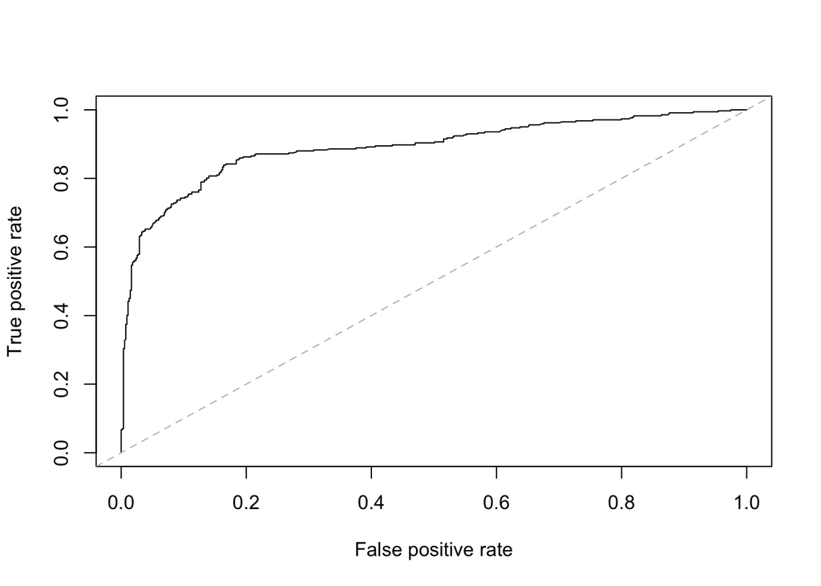

```r
pre=predict(model7,type='response')
m=prediction(pre,train$Survived)
plot(performance(m,'tpr','fpr'))
abline(0,1, lty = 8, col = "grey")
```

```r
auc <- performance(m, "auc")@y.values
auc
```

```
## [[1]]
## [1] 0.8902923
```

ROC curve如果越接近灰色虛線的話代表這個模型判斷能力越不好  
這個模型的ROC curve離虛線滿遠的，再算AUC  
AUC算出來為0.89，這個模型算擁有滿好的判別能力

### 第四步驟 model放入testing data

```r
pre=predict(model7,test)
p<-exp(pre)/(1+exp(pre))
test$odds<-p
test$sur[test$odds>0.5]<-1
test$sur[test$odds<=0.5]<-0
test$correct<-full[892:1309,]$Survived
acc=sum(test$sur==test$correct)/nrow(test)
table(test$sur,test$correct)
```

```
##
##       0   1
##   0 250  16
##   1  16 136
```

confusion table結果為真實0預測0真實1預測1的結果有386  
正確率高達0.92

### 補充

若在第一步驟中，原模型與有交互作用項的模型做Chunk test若不顯著，就代表沒有交互作用對我們模型有幫助，但資料的變數太多，就會需要選出重要的Confundings (也就是上面的V)  
如何選出重要的Confundings： 將原模型的Odds ratio與刪掉一個Confunding模型的Odds ratio做比較，若Odds ratio或信賴區間比較小，那就可以刪掉那個Confunding

# 多分類Logistic Regression

當依變數的分類有三個以上時

### 第一步驟 選出重要的E

```r
ml$prog2 <- relevel(ml$prog, ref = "academic")
test <- multinom(prog2 ~., data = ml[,-1])
test1 <- multinom(prog2 ~ ses*(female+schtyp+read+math+science+
                                   socst+honors+awards+cid+write), data = ml)
lrtest(test,test1)
```

```
## Likelihood ratio test
##
## Model 1: prog2 ~ female + ses + schtyp + prog + read + write + math +
##     science + socst + honors + awards + cid
## Model 2: prog2 ~ ses * (female + schtyp + read + math + science + socst +
##     honors + awards + cid + write)
##   #Df  LogLik Df Chisq Pr(>Chisq)
## 1  30   0.000
## 2  66 -91.102 36 182.2  < 2.2e-16 ***
## ---
## Signif. codes:  0 '***' 0.001 '**' 0.01 '*' 0.05 '.' 0.1 ' ' 1
```

```r
summary(test1)
```

```
## Call:
## multinom(formula = prog2 ~ ses * (female + schtyp + read + math +
##     science + socst + honors + awards + cid + write), data = ml)
##
## Coefficients:
##          (Intercept) sesmiddle   seshigh femalefemale schtypprivate
## general     95.08234 -93.05279 11.259537   -0.5714676     56.270123
## vocation   105.19758 -91.34384 -2.314376    0.6960586     -3.564365
##                read       math    science       socst honorsenrolled
## general  -0.8089763 -0.9131650 -0.4053574 -0.02513044       1.843223
## vocation -0.8634029 -0.7656441 -0.4982495 -0.31691684      10.669173
##             awards      cid      write sesmiddle:femalefemale
## general  -1.525883 3.298430 -0.3048445              1.3800023
## vocation -3.367629 2.877954 -0.2348896              0.2039817
##          seshigh:femalefemale sesmiddle:schtypprivate
## general              96.96587              -57.063311
## vocation            -37.54302                2.306433
##          seshigh:schtypprivate sesmiddle:read seshigh:read sesmiddle:math
## general             -37.158565      0.8639196    -5.316630      0.9204465
## vocation             -7.316076      0.8411093     3.072455      0.6619990
##          seshigh:math sesmiddle:science seshigh:science sesmiddle:socst
## general      9.605659         0.4799359        2.897798    -0.006836424
## vocation    -4.707959         0.5332641       -2.666502     0.269018299
##          seshigh:socst sesmiddle:honorsenrolled seshigh:honorsenrolled
## general      -1.259433                -1.546854              -77.82165
## vocation     -5.588321               -10.023632               21.26497
##          sesmiddle:awards seshigh:awards sesmiddle:cid seshigh:cid
## general          1.698869       61.10085      -3.41453   -8.434882
## vocation         3.421685      -97.39806      -2.78919    3.407775
##          sesmiddle:write seshigh:write
## general       0.16490313     -8.559986
## vocation      0.07278895     10.841808
##
## Std. Errors:
##          (Intercept) sesmiddle      seshigh femalefemale schtypprivate
## general     4.318833  3.980487 1.129314e-02     1.536560     0.3956540
## vocation    4.685863  4.413594 7.923671e-06     2.118792     0.4443894
##               read      math   science      socst honorsenrolled   awards
## general  0.1165813 0.1194508 0.1147280 0.08961488       2.836455 1.200901
## vocation 0.1366740 0.1811705 0.1382698 0.11455726       5.033904 1.977795
```

[output cut: 9 more lines]

```
##          seshigh:science sesmiddle:socst seshigh:socst
## general     0.7082454866      0.09893322  0.4102163257
## vocation    0.0004199485      0.12162086  0.0004436809
##          sesmiddle:honorsenrolled seshigh:honorsenrolled sesmiddle:awards
## general                  3.167509           9.094125e-03         1.402553
## vocation                 5.256713           6.822173e-19         2.109397
##          seshigh:awards sesmiddle:cid  seshigh:cid sesmiddle:write
## general    3.111353e-02     0.4068034 1.453616e-01       0.1712234
## vocation   7.752328e-09     0.5668809 7.925295e-05       0.1842088
##          seshigh:write
## general   0.6780046572
## vocation  0.0003487073
##
## Residual Deviance: 182.2037
## AIC: 314.2037
```

```r
z <- summary(test1)$coefficients/summary(test1)$standard.errors
z
```

```
##          (Intercept) sesmiddle      seshigh femalefemale schtypprivate
## general     22.01575 -23.37724     997.0242   -0.3719137    142.220516
## vocation    22.44999 -20.69602 -292083.8057    0.3285167     -8.020816
##               read      math   science     socst honorsenrolled    awards
## general  -6.939157 -7.644694 -3.533203 -0.280427      0.6498334 -1.270615
## vocation -6.317244 -4.226097 -3.603458 -2.766449      2.1194628 -1.702719
##               cid     write sesmiddle:femalefemale seshigh:femalefemale
## general  9.199541 -2.058199             0.81425495         8.586261e+03
## vocation 5.267484 -1.445338             0.09105784        -4.617454e+09
##          sesmiddle:schtypprivate seshigh:schtypprivate sesmiddle:read
## general              -144.216858         -4.085942e+03       6.720856
## vocation                5.190118         -1.077219e+19       5.694945
##          seshigh:read sesmiddle:math seshigh:math sesmiddle:science
## general      -10.0433       7.208156     16.47497          3.688312
## vocation    6155.1081       3.495841 -12639.86129          3.608983
##          seshigh:science sesmiddle:socst seshigh:socst
## general         4.091516      -0.0691014     -3.070167
## vocation    -6349.592639       2.2119420 -12595.361097
##          sesmiddle:honorsenrolled seshigh:honorsenrolled sesmiddle:awards
## general                -0.4883503          -8.557355e+03         1.211269
## vocation               -1.9068248           3.117037e+19         1.622115
##          seshigh:awards sesmiddle:cid seshigh:cid sesmiddle:write
## general    1.963803e+03     -8.393563   -58.02688       0.9630878
## vocation  -1.256372e+10     -4.920239 42998.72184       0.3951436
##          seshigh:write
## general      -12.62526
## vocation   31091.42735
```

```r
p <- (1 - pnorm(abs(z), 0, 1))*2
p
```

```
##          (Intercept) sesmiddle seshigh femalefemale schtypprivate
## general            0         0       0    0.7099571  0.000000e+00
## vocation           0         0       0    0.7425211  1.110223e-15
##                  read         math      science      socst honorsenrolled
## general  3.944400e-12 2.087219e-14 0.0004105577 0.77914989     0.51579983
## vocation 2.662697e-10 2.377790e-05 0.0003140111 0.00566704     0.03405137
##             awards         cid      write sesmiddle:femalefemale
## general  0.2038656 0.00000e+00 0.03957102              0.4154989
## vocation 0.0886207 1.38306e-07 0.14836295              0.9274466
##          seshigh:femalefemale sesmiddle:schtypprivate
## general                     0            0.000000e+00
## vocation                    0            2.101614e-07
##          seshigh:schtypprivate sesmiddle:read seshigh:read sesmiddle:math
## general                      0   1.806599e-11            0   5.671019e-13
## vocation                     0   1.234119e-08            0   4.725709e-04
##          seshigh:math sesmiddle:science seshigh:science sesmiddle:socst
## general             0      0.0002257468    4.285627e-05      0.94490891
## vocation            0      0.0003074000    0.000000e+00      0.02697067
##          seshigh:socst sesmiddle:honorsenrolled seshigh:honorsenrolled
## general    0.002139389               0.62530172                      0
## vocation   0.000000000               0.05654327                      0
##          sesmiddle:awards seshigh:awards sesmiddle:cid seshigh:cid
## general         0.2257924              0  0.000000e+00           0
## vocation        0.1047787              0  8.643851e-07           0
##          sesmiddle:write seshigh:write
## general        0.3355034             0
## vocation       0.6927369             0
```

### 第二步驟 找到Golden Standard Model

```r
summary(test3)
```

```
## Call:
## multinom(formula = prog2 ~ ses * (schtyp + read + math + socst +
##     honors + awards + cid + write), data = ml)
##
## Coefficients:
##          (Intercept) sesmiddle   seshigh schtypprivate       read
## general     41.04681 -31.75786  31.23866      17.87744 -0.4281446
## vocation    42.62237 -26.80860 -31.39900      -2.57763 -0.4390571
##                math       socst honorsenrolled     awards       cid
## general  -0.5230592 -0.04137586      0.8484857 -0.9546853 1.3056643
## vocation -0.3329045 -0.29085632      9.1175198 -1.8374754 0.3940069
##                write sesmiddle:schtypprivate seshigh:schtypprivate
## general  -0.04854729              -18.654115            -34.739977
## vocation  0.05600426                1.281799             -3.863103
##          sesmiddle:read seshigh:read sesmiddle:math seshigh:math
## general       0.4313768   -1.3161363      0.4752118     5.206416
## vocation      0.3993674    0.1780964      0.2070577    -3.623518
##          sesmiddle:socst seshigh:socst sesmiddle:honorsenrolled
## general       0.01610473     -2.755900                -0.510819
## vocation      0.24905538     -1.463439                -8.483241
##          seshigh:honorsenrolled sesmiddle:awards seshigh:awards
## general               -99.25011        0.9884951       32.12854
## vocation               21.83603        1.8237589      -72.50033
##          sesmiddle:cid seshigh:cid sesmiddle:write seshigh:write
## general     -1.1561102  -1.8283791     -0.09696693     -2.203208
## vocation    -0.2401008   0.3917051     -0.18951868      6.459628
##
## Std. Errors:
##          (Intercept) sesmiddle    seshigh schtypprivate       read
## general     3.649106  3.383584 0.04924224     0.4102165 0.09149665
## vocation    3.636745  3.446045 0.08293232     0.4445473 0.11370448
##               math      socst honorsenrolled   awards       cid     write
## general  0.1071041 0.08018135       2.803284 1.002650 0.2491004 0.1301853
## vocation 0.1650137 0.11242129       4.702489 1.755669 0.4717549 0.1456387
##          sesmiddle:schtypprivate seshigh:schtypprivate sesmiddle:read
## general                0.4133342          0.2857994639      0.1041357
## vocation               0.4445478          0.0001409081      0.1262467
##          seshigh:read sesmiddle:math seshigh:math sesmiddle:socst
## general      1.173150      0.1144740     2.817695      0.08998045
## vocation     1.293584      0.1684974     1.101959      0.11937853
##          seshigh:socst sesmiddle:honorsenrolled seshigh:honorsenrolled
## general       1.626511                 3.125857           3.310239e-01
## vocation      2.912357                 4.937566           1.352731e-18
##          sesmiddle:awards seshigh:awards sesmiddle:cid seshigh:cid
## general          1.214446      0.3838864     0.2993009    1.562563
## vocation         1.892982      0.1662693     0.4995785    1.304129
##          sesmiddle:write seshigh:write
## general        0.1535530      1.056920
## vocation       0.1675462      1.413964
##
## Residual Deviance: 188.4463
## AIC: 296.4463
```

跑出來的結果是這樣的
$$log\frac{P(prog2=general)}{P(prog2=academic)} =\alpha+\beta E+\gamma_1 V_1+\gamma_2 V_2+...+E\delta_1 W_1+E\delta_2 W_2+...+E\delta_j W_j$$

多分類的Logistic Regression沒有ROC  
那直接來預測看看！

```r
exp(coef(test3))
```

```
##           (Intercept)    sesmiddle      seshigh schtypprivate      read
## general  6.705077e+17 1.613376e-14 3.687903e+13  5.808634e+07 0.6517171
## vocation 3.240843e+18 2.276002e-12 2.309868e-14  7.595377e-02 0.6446440
##               math     socst honorsenrolled    awards      cid     write
## general  0.5927046 0.9594684       2.336107 0.3849333 3.690139 0.9526123
## vocation 0.7168387 0.7476231    9113.570320 0.1592189 1.482911 1.0576022
##          sesmiddle:schtypprivate seshigh:schtypprivate sesmiddle:read
## general             7.918100e-09          8.177480e-16       1.539375
## vocation            3.603114e+00          2.100272e-02       1.490881
##          seshigh:read sesmiddle:math seshigh:math sesmiddle:socst
## general     0.2681694       1.608355 182.43903932        1.016235
## vocation    1.1949405       1.230053   0.02668862        1.282813
##          seshigh:socst sesmiddle:honorsenrolled seshigh:honorsenrolled
## general     0.06355179              0.600003963           7.874519e-44
## vocation    0.23143897              0.000206907           3.042755e+09
##          sesmiddle:awards seshigh:awards sesmiddle:cid seshigh:cid
## general          2.687187   8.979451e+13     0.3147079   0.1606738
## vocation         6.195101   3.262162e-32     0.7865485   1.4795013
##          sesmiddle:write seshigh:write
## general        0.9075860     0.1104483
## vocation       0.8273573   638.8231004
```

```r
pp.write <- cbind(dses, predict(test3, newdata = dses, type = "probs", se = TRUE))
head(pp.write[1:5,15:17])
```

```
##         academic      general      vocation
## 161 1.933226e-17 1.000000e+00 2.255729e-180
## 162 1.000000e+00 2.315119e-43  1.439221e-94
## 163 9.882346e-01 1.173454e-02  3.090992e-05
## 164 2.453848e-16 1.000000e+00  1.823380e-55
## 165 7.314462e-01 2.248696e-01  4.368422e-02
```

出來的結果直接是機率，機率越大，代表就是這個分類  
接下來看預測正確率有多少

```
##
##            academic general
##   academic       28       3
##   general         4       2
##   vocation        2       1
```

正確率0.75